# EDA- Exploratory Data Analysis

## Steps to follow for Data Analysis Projects

1. Understand the Data - Read the descriptions of the columns, understand what kind of data is being stored
2. Data Gathering
3. Check the data quality - Duplicated rows, Missing content, Outliers
4. Data Cleaning - handling of missing data - pipelines Duplicated row handling, Missing data handling,Handling outliers
5. Statistical Analysis - describe() - categotrical data as well as for continuous data
6. Descriptive Analysis

   ```
   Univariate Analysis - Analysis of single variable/feature

   Bivariate Analysis - Analysis of 2 variables/features

   Multivariate Analysis - Analysis of more than 2 variable/features
   ```

7. Documentation - Include a cell where you discuss all the Insights gathered. You can mention Recommendations also.

## Data Gathering - Read the dataset

```python
import pandas as pd
df = pd.read_csv(r"E:\Sindhura\DataSets\laptopPrice.csv")
df.head()
```

|  | brand | processor_brand | processor_name | processor_gnrtn | ram_gb | ram_type | ssd | hdd | os | os_bit | graphic_card_gb | weight | warranty | Touchscreen | msoffice | Price | rating | Number of Ratings | Number of Reviews |
| --- | --- | --- | --- | --- | --- | --- | --- | --- | --- | --- | --- | --- | --- | --- | --- | --- | --- | --- | --- |
| 0 | ASUS | Intel | Core i3 | 10th | 4 GB | DDR4 | 0 GB | 1024 GB | Windows | 64-bit | 0 GB | Casual | No warranty | No | No | 34649 | 2 stars | 3 | 0 |
| 1 | Lenovo | Intel | Core i3 | 10th | 4 GB | DDR4 | 0 GB | 1024 GB | Windows | 64-bit | 0 GB | Casual | No warranty | No | No | 38999 | 3 stars | 65 | 5 |
| 2 | Lenovo | Intel | Core i3 | 10th | 4 GB | DDR4 | 0 GB | 1024 GB | Windows | 64-bit | 0 GB | Casual | No warranty | No | No | 39999 | 3 stars | 8 | 1 |
| 3 | ASUS | Intel | Core i5 | 10th | 8 GB | DDR4 | 512 GB | 0 GB | Windows | 32-bit | 2 GB | Casual | No warranty | No | No | 69990 | 3 stars | 0 | 0 |
| 4 | ASUS | Intel | Celeron Dual | Not Available | 4 GB | DDR4 | 0 GB | 512 GB | Windows | 64-bit | 0 GB | Casual | No warranty | No | No | 26990 | 3 stars | 0 | 0 |

## Perform the data quality checks

```python
df.shape
```

```
(823, 19)
```

```python
df.columns
```

```
Index(['brand', 'processor_brand', 'processor_name', 'processor_gnrtn',
       'ram_gb', 'ram_type', 'ssd', 'hdd', 'os', 'os_bit', 'graphic_card_gb',
       'weight', 'warranty', 'Touchscreen', 'msoffice', 'Price', 'rating',
       'Number of Ratings', 'Number of Reviews'],
      dtype='object')
```

```python
df.info()
```

```
<class 'pandas.core.frame.DataFrame'>
RangeIndex: 823 entries, 0 to 822
Data columns (total 19 columns):
 #   Column             Non-Null Count  Dtype
---  ------             --------------  -----
 0   brand              823 non-null    object
 1   processor_brand    823 non-null    object
 2   processor_name     823 non-null    object
 3   processor_gnrtn    823 non-null    object
 4   ram_gb             823 non-null    object
 5   ram_type           823 non-null    object
 6   ssd                823 non-null    object
 7   hdd                823 non-null    object
 8   os                 823 non-null    object
 9   os_bit             823 non-null    object
 10  graphic_card_gb    823 non-null    object
 11  weight             823 non-null    object
 12  warranty           823 non-null    object
 13  Touchscreen        823 non-null    object
 14  msoffice           823 non-null    object
 15  Price              823 non-null    int64
 16  rating             823 non-null    object
 17  Number of Ratings  823 non-null    int64
 18  Number of Reviews  823 non-null    int64
dtypes: int64(3), object(16)
memory usage: 122.3+ KB
```

```python
## Duplicated rows
df.duplicated().sum()
```

```
np.int64(21)
```

### There are around 21 duplicated rows in the current dataset. We will be removing those duplicated rows.

```python
## Drop the duplciates
print(df.shape)
df = df.drop_duplicates()
print(f"After removal of duplicated rows: {df.shape}")
```

```
(823, 19)
After removal of duplicated rows: (802, 19)
```

```python
## Check for Missing values
df.isna().sum()
```

```
brand                0
processor_brand      0
processor_name       0
processor_gnrtn      0
ram_gb               0
ram_type             0
ssd                  0
hdd                  0
os                   0
os_bit               0
graphic_card_gb      0
weight               0
warranty             0
Touchscreen          0
msoffice             0
Price                0
rating               0
Number of Ratings    0
Number of Reviews    0
dtype: int64
```

## There are no missing values in this dataset

## Separate the data into categorical and continuous

```python
cat = list(df.columns[df.dtypes=="object"])
con = list(df.columns[df.dtypes!="object"])
```

```python
print(df.columns)
```

```
Index(['brand', 'processor_brand', 'processor_name', 'processor_gnrtn',
       'ram_gb', 'ram_type', 'ssd', 'hdd', 'os', 'os_bit', 'graphic_card_gb',
       'weight', 'warranty', 'Touchscreen', 'msoffice', 'Price', 'rating',
       'Number of Ratings', 'Number of Reviews'],
      dtype='object')
```

```python
print(cat)
```

```
['brand', 'processor_brand', 'processor_name', 'processor_gnrtn', 'ram_gb', 'ram_type', 'ssd', 'hdd', 'os', 'os_bit', 'graphic_card_gb', 'weight', 'warranty', 'Touchscreen', 'msoffice', 'rating']
```

```python
print(con)
```

```
['Price', 'Number of Ratings', 'Number of Reviews']
```

## Pipeline that handles Data cleaning process

Though in current dataset, we dont have missing data, however, in future we may come across new data that contains missing data

```python
# Import Pipeline
from sklearn.pipeline import make_pipeline
# Import Imputer that performs missing data handling by replacing missing data with central tendency
from sklearn.impute import SimpleImputer
# Column Transformer combines pipelines. Here we have 2 pipelines- categorical and continuous
from sklearn.compose import ColumnTransformer
```

```python
# pipeline to handle numerical missing content
num_pipe = make_pipeline(SimpleImputer(strategy="median"))

# pipeline to handle categorical missing content
cat_pipe = make_pipeline(SimpleImputer(strategy="most_frequent"))
```

```python
# combine both the pipelines
final_pipe = ColumnTransformer([
    ('cat',cat_pipe,cat),
    ('con',num_pipe,con)
]).set_output(transform="pandas")
```

```python
final_pipe
```

```
ColumnTransformer(transformers=[('cat',
                                 Pipeline(steps=[('simpleimputer',
                                                  SimpleImputer(strategy='most_frequent'))]),
                                 ['brand', 'processor_brand', 'processor_name',
                                  'processor_gnrtn', 'ram_gb', 'ram_type',
                                  'ssd', 'hdd', 'os', 'os_bit',
                                  'graphic_card_gb', 'weight', 'warranty',
                                  'Touchscreen', 'msoffice', 'rating']),
                                ('con',
                                 Pipeline(steps=[('simpleimputer',
                                                  SimpleImputer(strategy='median'))]),
                                 ['Price', 'Number of Ratings',
                                  'Number of Reviews'])])
```

```python
df_cleaned = final_pipe.fit_transform(df)
df_cleaned.head(3)
```

|  | cat__brand | cat__processor_brand | cat__processor_name | cat__processor_gnrtn | cat__ram_gb | cat__ram_type | cat__ssd | cat__hdd | cat__os | cat__os_bit | cat__graphic_card_gb | cat__weight | cat__warranty | cat__Touchscreen | cat__msoffice | cat__rating | con__Price | con__Number of Ratings | con__Number of Reviews |
| --- | --- | --- | --- | --- | --- | --- | --- | --- | --- | --- | --- | --- | --- | --- | --- | --- | --- | --- | --- |
| 0 | ASUS | Intel | Core i3 | 10th | 4 GB | DDR4 | 0 GB | 1024 GB | Windows | 64-bit | 0 GB | Casual | No warranty | No | No | 2 stars | 34649.0 | 3.0 | 0.0 |
| 1 | Lenovo | Intel | Core i3 | 10th | 4 GB | DDR4 | 0 GB | 1024 GB | Windows | 64-bit | 0 GB | Casual | No warranty | No | No | 3 stars | 38999.0 | 65.0 | 5.0 |
| 2 | Lenovo | Intel | Core i3 | 10th | 4 GB | DDR4 | 0 GB | 1024 GB | Windows | 64-bit | 0 GB | Casual | No warranty | No | No | 3 stars | 39999.0 | 8.0 | 1.0 |

```python
new_cols = []
for i in df_cleaned.columns:
    c = i.split('__')[-1]
    new_cols.append(c)
print(new_cols)
```

```
['brand', 'processor_brand', 'processor_name', 'processor_gnrtn', 'ram_gb', 'ram_type', 'ssd', 'hdd', 'os', 'os_bit', 'graphic_card_gb', 'weight', 'warranty', 'Touchscreen', 'msoffice', 'rating', 'Price', 'Number of Ratings', 'Number of Reviews']
```

```python
df_cleaned.columns
```

```
Index(['cat__brand', 'cat__processor_brand', 'cat__processor_name',
       'cat__processor_gnrtn', 'cat__ram_gb', 'cat__ram_type', 'cat__ssd',
       'cat__hdd', 'cat__os', 'cat__os_bit', 'cat__graphic_card_gb',
       'cat__weight', 'cat__warranty', 'cat__Touchscreen', 'cat__msoffice',
       'cat__rating', 'con__Price', 'con__Number of Ratings',
       'con__Number of Reviews'],
      dtype='object')
```

```python
df_cleaned.columns = new_cols
df_cleaned.columns
```

```
Index(['brand', 'processor_brand', 'processor_name', 'processor_gnrtn',
       'ram_gb', 'ram_type', 'ssd', 'hdd', 'os', 'os_bit', 'graphic_card_gb',
       'weight', 'warranty', 'Touchscreen', 'msoffice', 'rating', 'Price',
       'Number of Ratings', 'Number of Reviews'],
      dtype='object')
```

```python
df_cleaned.head()
```

|  | brand | processor_brand | processor_name | processor_gnrtn | ram_gb | ram_type | ssd | hdd | os | os_bit | graphic_card_gb | weight | warranty | Touchscreen | msoffice | rating | Price | Number of Ratings | Number of Reviews |
| --- | --- | --- | --- | --- | --- | --- | --- | --- | --- | --- | --- | --- | --- | --- | --- | --- | --- | --- | --- |
| 0 | ASUS | Intel | Core i3 | 10th | 4 GB | DDR4 | 0 GB | 1024 GB | Windows | 64-bit | 0 GB | Casual | No warranty | No | No | 2 stars | 34649.0 | 3.0 | 0.0 |
| 1 | Lenovo | Intel | Core i3 | 10th | 4 GB | DDR4 | 0 GB | 1024 GB | Windows | 64-bit | 0 GB | Casual | No warranty | No | No | 3 stars | 38999.0 | 65.0 | 5.0 |
| 2 | Lenovo | Intel | Core i3 | 10th | 4 GB | DDR4 | 0 GB | 1024 GB | Windows | 64-bit | 0 GB | Casual | No warranty | No | No | 3 stars | 39999.0 | 8.0 | 1.0 |
| 3 | ASUS | Intel | Core i5 | 10th | 8 GB | DDR4 | 512 GB | 0 GB | Windows | 32-bit | 2 GB | Casual | No warranty | No | No | 3 stars | 69990.0 | 0.0 | 0.0 |
| 4 | ASUS | Intel | Celeron Dual | Not Available | 4 GB | DDR4 | 0 GB | 512 GB | Windows | 64-bit | 0 GB | Casual | No warranty | No | No | 3 stars | 26990.0 | 0.0 | 0.0 |

```python
df_cleaned.to_csv('Cleaned Dataset.csv')
```

```python
df_cleaned.to_csv('Cleaned Dataset2.csv',index=False)
```

```python
## Handling Outliers
```

## Statistical Analysis

```python
df[con].describe().T
# df.describe()
```

|  | count | mean | std | min | 25% | 50% | 75% | max |
| --- | --- | --- | --- | --- | --- | --- | --- | --- |
| Price | 802.0 | 76625.543641 | 45232.984422 | 16990.0 | 45990.0 | 63990.0 | 89525.00 | 441990.0 |
| Number of Ratings | 802.0 | 299.844140 | 1001.784420 | 0.0 | 0.0 | 17.0 | 140.25 | 15279.0 |
| Number of Reviews | 802.0 | 36.089776 | 118.313553 | 0.0 | 0.0 | 2.0 | 18.00 | 1947.0 |

```python
df[cat].describe().T
```

|  | count | unique | top | freq |
| --- | --- | --- | --- | --- |
| brand | 802 | 8 | ASUS | 243 |
| processor_brand | 802 | 3 | Intel | 594 |
| processor_name | 802 | 11 | Core i5 | 284 |
| processor_gnrtn | 802 | 8 | 11th | 328 |
| ram_gb | 802 | 4 | 8 GB | 404 |
| ram_type | 802 | 6 | DDR4 | 690 |
| ssd | 802 | 7 | 512 GB | 389 |
| hdd | 802 | 4 | 0 GB | 602 |
| os | 802 | 3 | Windows | 763 |
| os_bit | 802 | 2 | 64-bit | 693 |
| graphic_card_gb | 802 | 5 | 0 GB | 557 |
| weight | 802 | 3 | Casual | 509 |
| warranty | 802 | 4 | 1 year | 498 |
| Touchscreen | 802 | 2 | No | 706 |
| msoffice | 802 | 2 | No | 522 |
| rating | 802 | 5 | 4 stars | 437 |

### More than 50% data contains below types of features majorly

```
Most of the laptops are casual weight, they are providing Intel processor brand with 8GB ram and DDR4 RAM type.
hdd- 0GB
os-bit - 64bit
Not providing any Graphic card.
Not providing touchscreen, msoffice.
Providing a warranty of 1 year
ratings are 4stars
```

## Visualization : Extracting meaningful insights from different different visuals

## Univariate Analysis

```
Analysis of single variable - feature
Categorical Analysis - Bar plots
Continuous Analysis - Histogram
```

# Bar plots

[figure not shown]

```python
print(cat)
```

```
['brand', 'processor_brand', 'processor_name', 'processor_gnrtn', 'ram_gb', 'ram_type', 'ssd', 'hdd', 'os', 'os_bit', 'graphic_card_gb', 'weight', 'warranty', 'Touchscreen', 'msoffice', 'rating']
```

```python
df_cleaned['brand'].value_counts()
```

```
brand
ASUS      243
DELL      149
Lenovo    144
HP        136
acer       51
MSI        50
APPLE      23
Avita       6
Name: count, dtype: int64
```

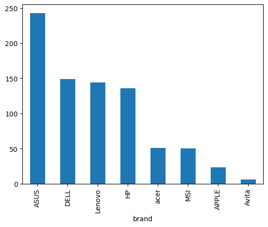

```python
df_cleaned['brand'].value_counts().plot(kind='bar')
```

Avita brand laptops are very few

ASUS brand laptops are very high

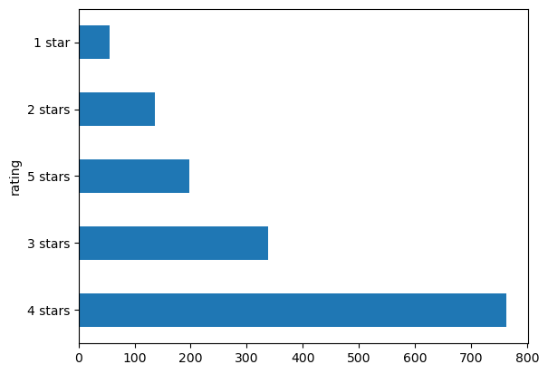

```python
import matplotlib.pyplot as plt
for i in cat:
    df_cleaned[i].value_counts().plot(kind='barh')
    #plt.show()
```

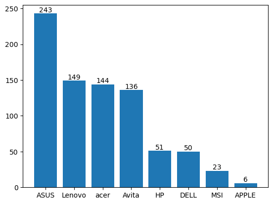

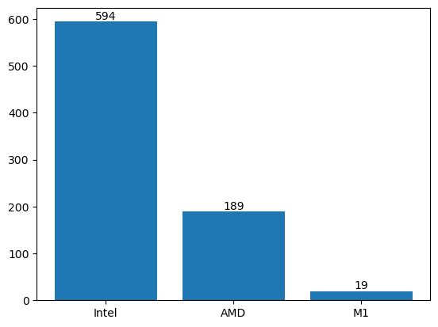

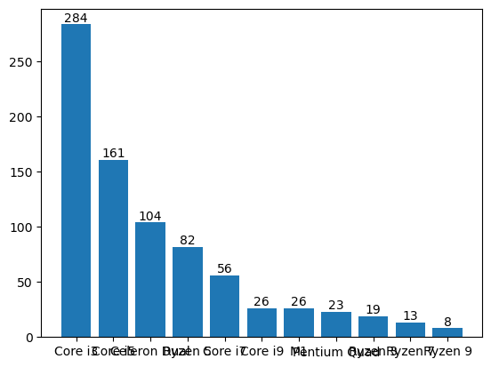

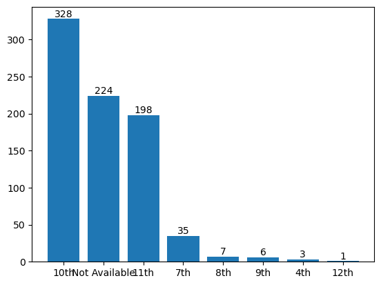

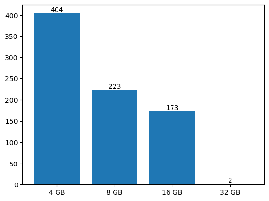

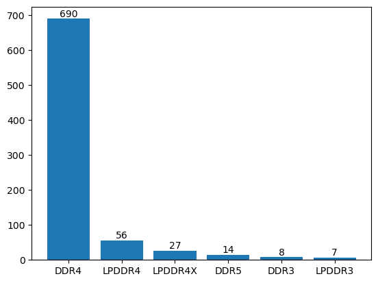

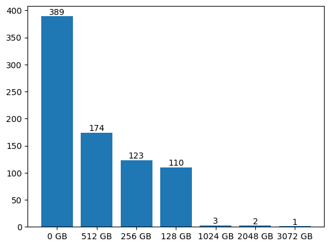

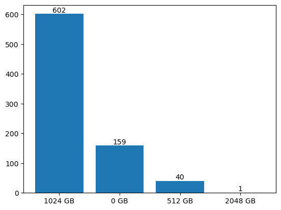

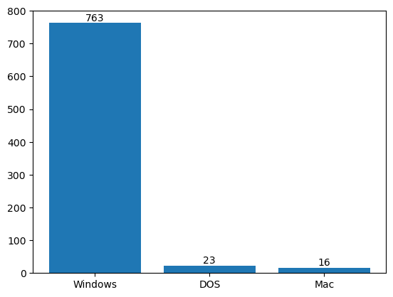

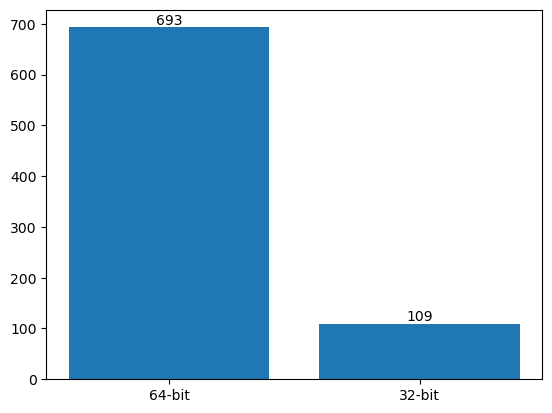

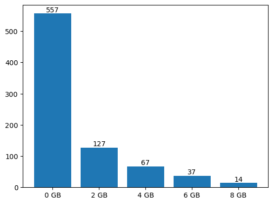

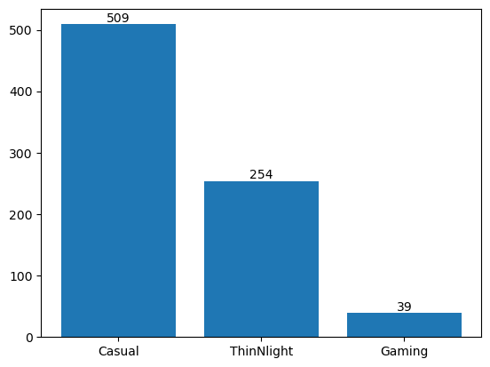

[4 more figures not shown]

```python
for i in cat:
    br = plt.bar(df_cleaned[i].unique(),df_cleaned[i].value_counts())
    plt.bar_label(br)
    plt.show()
```

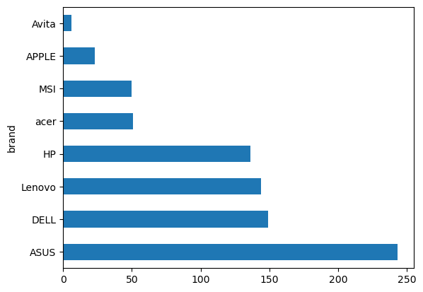

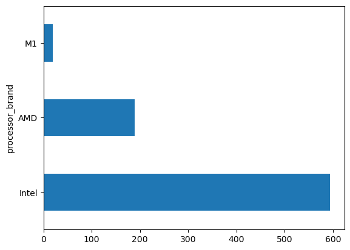

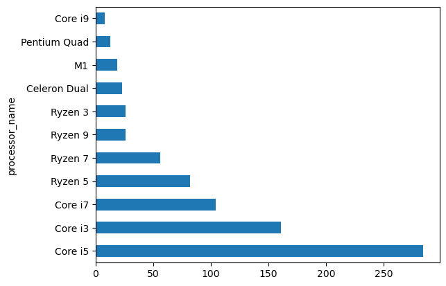

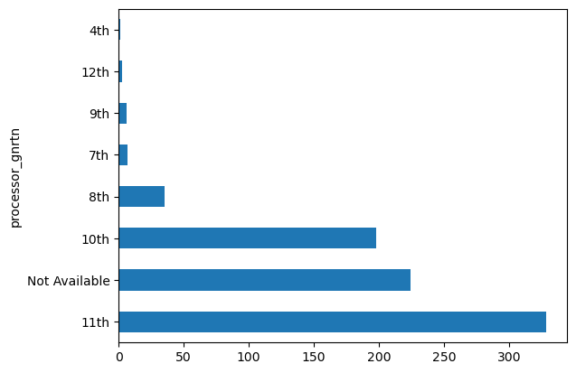

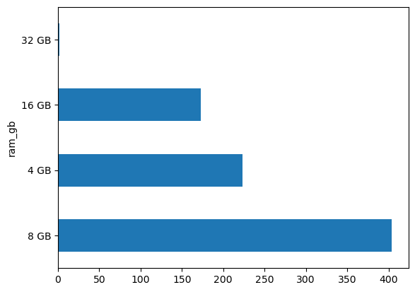

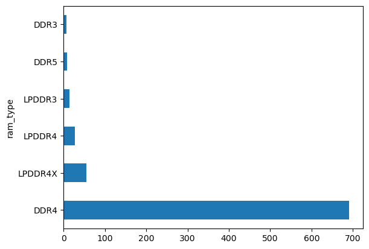

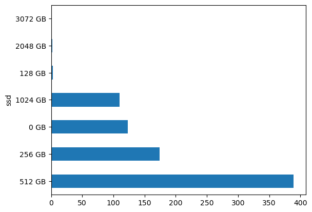

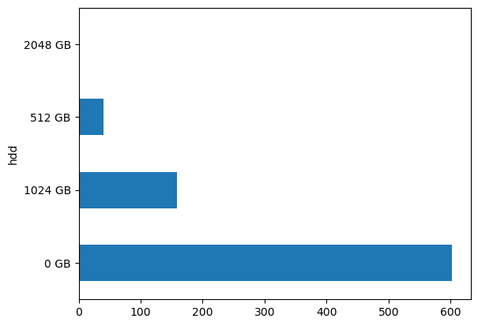

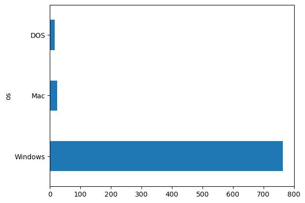

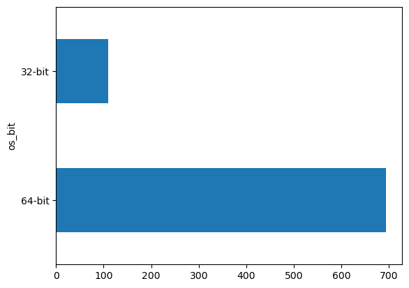

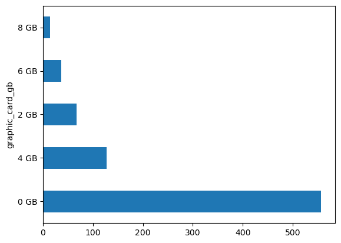

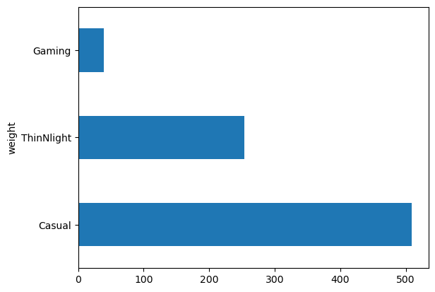

[4 more figures not shown]

```python
for i in cat:
    df_cleaned[i].value_counts().plot(kind='barh')
    plt.show()
```

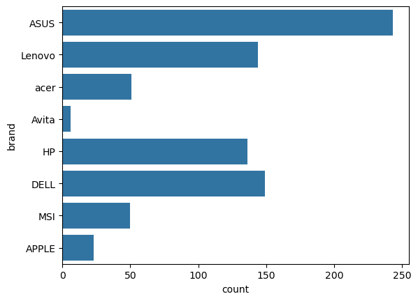

```python
import seaborn as sns
sns.countplot(df_cleaned['brand'])
```